# LLM analysis

```r
library(tidyverse)
library(here)
library(xtable)
library(kableExtra)
source("helper_functions.R", local = knitr::knit_global())
select <- dplyr::select
```

Set up some helper functions to compute gain for a category:

```r
# safe log
safelog <- function(p) {
  ifelse(is.na(p) | p == 0, 0, -log2(p))
}

# gain estimation function
gain_identity <- function(p_c_x, p_t, m_t) {
  gain <- p_t / m_t * safelog(p_c_x)
}
```

Prepare prior need probability data:

```r
# load feature and frequency data
d <- read_csv(here("data", "d_leuven.csv"), show_col_types = FALSE)

# prepare a prior need data
p_c <- d %>%
  group_by(category, level, domain) %>%
  summarise(p_c = sum(p)) %>%
  ungroup()
```

## Identity model

Prepare a dataframe on context-dependent probabilities:

```r
probs <- read_csv(here("data/probs", "all_probs.csv"), show_col_types = FALSE)

p_c_x <- probs %>%
  # create unique sentence identifier
  mutate(sent_id = paste0(domain, "_", row_id, "_", target_word)) %>%
  select(sent_id, target_word, probe_word, prob_norm) %>%
  # add category information
  left_join(d %>% distinct(probe_word=target_word, probe_category=category), by = "probe_word") %>%
  group_by(sent_id, target_word, probe_category) %>%
  # compute probability of category c given context x
  summarise(p_c_x = sum(prob_norm)) %>%
  ungroup() %>%
  left_join(d %>% distinct(target_word, target_category=category), by = "target_word") %>%
  # retain categories that correspond to target words
  filter(target_category == probe_category) %>%
  select(sent_id, category=target_category, target_word, p_c_x)

d_gain <- p_c %>%
  left_join(p_c_x, by = "category") %>%
  left_join(d %>% filter(level=="terminal") %>% distinct(target_word, target=category) , by = "target_word") %>%
  left_join(p_c %>% distinct(target=category, p_t=p_c), by = "target") %>%
  select(-target_word, -p_c) %>%
  group_by(target) %>%
  mutate(m_t=n_distinct(sent_id)) %>%
  ungroup()
```

Compute gains:

```r
identity <- d_gain %>%
  # apply gain estimation function
  mutate(gain = gain_identity(p_c_x, p_t, m_t)) %>%
  # sum across all targets that belong to category c
  group_by(domain, level, category) %>%
  summarise(gain = sum(gain)) %>%
  ungroup()
```

Visualise a plot for contextual probabilities:

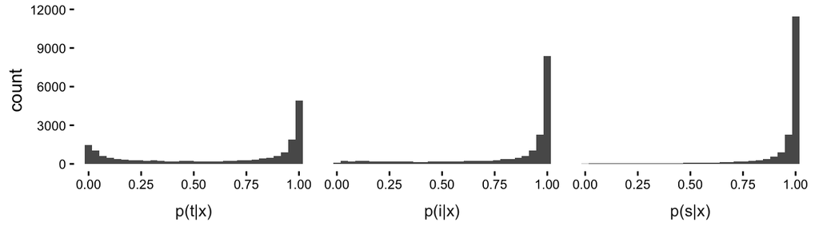

```r
plot <- d_gain %>%
  mutate(level = factor(level,
                        levels = c("terminal", "intermediate", "starting"))) %>%
  ggplot(aes(x = p_c_x)) +
  geom_histogram() +
  facet_grid(
    . ~ level,
    switch = "x",
    labeller = as_labeller(c(
      terminal = "p(t|x)",
      intermediate = "p(i|x)",
      starting = "p(s|x)"
    ))
  ) +
  theme_classic() +
  theme(
    strip.background = element_blank(),
    strip.placement = "outside",
    axis.text.x = element_text(size = 8),
    axis.text.y = element_text(size = 8),
    strip.text.x = element_text(size = 10),
    axis.line = element_blank(),
    axis.title.x = element_blank()
  )
plot
```

```r
ggsave(here("output/figures", "contextual_probabilities.pdf"), plot, width = 17.5, height = 6, units = "cm")
```

The plot suggests that the T5 model can correctly infer superordinate categories most of the time (the rightmost panel shows many cases where $p(s|x)$ is close to one).

Now summarise gain differences:

```r
id_bs <- identity %>%
  t_greater_than_s()
id_bs %>% kable()
```

| category | t_minus_s | t_greater_than_s | n_terminals | prop |
| --- | --- | --- | --- | --- |
| animals | -0.043272 | 0 | 108 | 0.00 |
| artifacts | -0.059488 | 1 | 147 | 0.01 |

```r
id_bi <- identity %>%
  t_greater_than_i()
id_bi %>% kable()
```

| category | t_minus_i | t_greater_than_i | n_terminals | prop |
| --- | --- | --- | --- | --- |
| birds | -0.0187661 | 0 | 29 | 0.00 |
| clothing | -0.0430525 | 0 | 22 | 0.00 |
| fish | -0.0045346 | 0 | 10 | 0.00 |
| insects | -0.0122609 | 0 | 22 | 0.00 |
| kitchen utensils | -0.0583386 | 0 | 32 | 0.00 |
| mammals | -0.0509438 | 0 | 27 | 0.00 |
| musical instruments | -0.0179818 | 0 | 24 | 0.00 |
| reptiles | -0.0102325 | 0 | 20 | 0.00 |
| tools | -0.0615889 | 0 | 26 | 0.00 |
| vehicles | -0.1140005 | 1 | 26 | 0.04 |
| weapons | -0.0352611 | 0 | 20 | 0.00 |

```r
identity %>%
  filter(domain == "animals") %>%
  arrange(desc(gain)) %>%
  head(10) %>% kable()
```

| domain | level | category | gain |
| --- | --- | --- | --- |
| animals | intermediate | mammals | 0.0570689 |
| animals | starting | animals | 0.0460782 |
| animals | terminal | dog | 0.0460577 |
| animals | terminal | horse | 0.0307567 |
| animals | terminal | cat | 0.0230086 |
| animals | intermediate | birds | 0.0207243 |
| animals | intermediate | insects | 0.0141542 |
| animals | intermediate | reptiles | 0.0116311 |
| animals | terminal | rabbit | 0.0072480 |
| animals | terminal | beetle | 0.0070147 |

```r
identity %>%
  filter(domain == "artifacts") %>%
  arrange(desc(gain)) %>%
  head(10) %>% kable()
```

| domain | level | category | gain |
| --- | --- | --- | --- |
| artifacts | terminal | car | 0.1330544 |
| artifacts | intermediate | vehicles | 0.1305690 |
| artifacts | starting | artifacts | 0.0684687 |
| artifacts | intermediate | tools | 0.0667173 |
| artifacts | intermediate | kitchen utensils | 0.0662898 |
| artifacts | intermediate | clothing | 0.0596458 |
| artifacts | terminal | train | 0.0416717 |
| artifacts | intermediate | weapons | 0.0402342 |
| artifacts | terminal | coat | 0.0393690 |
| artifacts | terminal | shirt | 0.0385351 |

## Feature model

We ran `07_LLM_analysis_features.R` to compute gains based on features. Now load the results and summarise:

```r
features <- read_csv(here("output/results", "llm_analysis_features.csv"), show_col_types = FALSE)

fe_bs <- features %>%
  t_greater_than_s()
fe_bs %>% kable()
```

| category | t_minus_s | t_greater_than_s | n_terminals | prop |
| --- | --- | --- | --- | --- |
| animals | -18.96036 | 0 | 108 | 0.00 |
| artifacts | -26.35181 | 1 | 147 | 0.01 |

```r
fe_bi <- features %>%
  t_greater_than_i
fe_bi %>% kable()
```

| category | t_minus_i | t_greater_than_i | n_terminals | prop |
| --- | --- | --- | --- | --- |
| birds | -2.7783756 | 0 | 29 | 0 |
| clothing | -11.3992456 | 0 | 22 | 0 |
| fish | -0.7371063 | 0 | 10 | 0 |
| insects | -2.0596441 | 0 | 22 | 0 |
| kitchen utensils | -10.1773783 | 0 | 32 | 0 |
| mammals | -17.7142385 | 0 | 27 | 0 |
| musical instruments | -3.8995688 | 0 | 24 | 0 |
| reptiles | -1.3224388 | 0 | 20 | 0 |
| tools | -9.9356327 | 0 | 26 | 0 |
| vehicles | -34.3323228 | 0 | 26 | 0 |
| weapons | -5.7174265 | 0 | 20 | 0 |

```r
features %>%
  filter(domain == "animals") %>%
  arrange(desc(gain)) %>%
  head(10) %>% kable()
```

| category | level | domain | gain |
| --- | --- | --- | --- |
| animals | starting | animals | 19.3352815 |
| mammals | intermediate | animals | 18.7730503 |
| dog | terminal | animals | 9.8921516 |
| horse | terminal | animals | 8.2162058 |
| cat | terminal | animals | 3.7745935 |
| birds | intermediate | animals | 2.9390002 |
| insects | intermediate | animals | 2.2211934 |
| reptiles | intermediate | animals | 1.4452130 |
| fish | intermediate | animals | 0.8606982 |
| mouse | terminal | animals | 0.7909150 |

```r
features %>%
  filter(domain == "artifacts") %>%
  arrange(desc(gain)) %>%
  head(10) %>% kable()
```

| category | level | domain | gain |
| --- | --- | --- | --- |
| vehicles | intermediate | artifacts | 36.961237 |
| car | terminal | artifacts | 29.790075 |
| artifacts | starting | artifacts | 27.425156 |
| clothing | intermediate | artifacts | 12.892124 |
| kitchen utensils | intermediate | artifacts | 11.061198 |
| tools | intermediate | artifacts | 10.551302 |
| weapons | intermediate | artifacts | 6.274499 |
| boat | terminal | artifacts | 6.101527 |
| train | terminal | artifacts | 5.774861 |
| knife | terminal | artifacts | 4.878428 |

Animals beat all their terminal level concepts and each five intermediate level concepts beat all their terminal level concepts. Artifacts beat all their terminal level categories except for car. Car has the highest frequency. All intermediate level categories also defeat their terminals in the artifact domain.

Make tables:

```r
leuven_bs <- id_bs %>%
  select(-t_greater_than_s, -n_terminals) %>%
  rename_with(~ paste0(.x, "_id"), -category) %>%
  left_join(
    fe_bs %>%
      select(-t_greater_than_s, -n_terminals) %>%
      rename_with(~ paste0(.x, "_fe"), -category),
    by = "category"
  )

leuven_bi <- id_bi %>%
  select(-t_greater_than_i, -n_terminals) %>%
  rename_with(~ paste0(.x, "_id"), -category) %>%
  left_join(
    fe_bi %>%
      select(-t_greater_than_i, -n_terminals) %>%
      rename_with(~ paste0(.x, "_fe"), -category),
    by = "category"
  )  %>%
  left_join(d %>% select(category, domain) %>% unique(), by = "category") %>%
  arrange(domain) %>% select(-domain)

leuven_bs_tb <- xtable(leuven_bs, digits = c(0, 0, 2, 2, 2, 2))
print(leuven_bs_tb, file = here("output", "tables", "leuven_t_minus_s_context.tex"), include.rownames = FALSE, comment = FALSE)

leuven_bi_tb <- xtable(leuven_bi, digits = c(0, 0, 2, 2, 2, 2))
print(leuven_bi_tb, file = here("output", "tables", "leuven_t_minus_i_context.tex"), include.rownames = FALSE, comment = FALSE)
```

## Spoken vs. written texts

We compare results for spoken texts only and written texts only.

```r
spoken_types <- c("OTHERSP", "CONVRSN")

probs <- probs %>%
  mutate(modality = if_else(doc_type %in% spoken_types, "spoken", "written"))

probs %>%
  distinct(modality, target_word) %>%
  group_by(modality) %>%
  summarise(n = n_distinct(target_word)) %>%
  ungroup() %>%
  kable()
```

| modality | n |
| --- | --- |
| spoken | 199 |
| written | 253 |

There are 199 concepts for spoken texts and 253 concepts for written texts. So, we first need to renormalize prior need and contextual probabilities across 199 concepts for spoken texts and 253 concepts for written texts.

```r
# prepare contextual probabilities for spoken texts
probs_spoken <- probs %>%
  filter(modality == "spoken") %>%
  # create unique sentence identifier
  mutate(sent_id = paste0(domain, "_", row_id, "_", target_word)) %>%
  select(sent_id, target_word, probe_word, prob_norm)

targets_spoken <- unique(probs_spoken$target_word)

probs_spoken <- probs_spoken %>%
  # filter probe words so that we work with 199 concepts only
  filter(probe_word %in% targets_spoken) %>%
  # normalize contextual probabilities
  group_by(sent_id, target_word) %>%
  mutate(total = sum(prob_norm)) %>%
  ungroup() %>%
  mutate(prob_norm = prob_norm / total) %>%
  select(-total)

# prepare a prior need data for spoken texts
p_c_spoken <- d %>%
  filter(target_word %in% targets_spoken)

total_p <- p_c_spoken %>%
  distinct(concept, p) %>%
  summarise(total_p = sum(p)) %>%
  pull(total_p)

p_c_spoken <- p_c_spoken %>%
  # normalize prior need probabilities
  mutate(p = p / total_p) %>%
  group_by(category, level, domain) %>%
  summarise(p_c = sum(p), .groups = "drop")

# prepare contextual probabilities for written texts
probs_written <- probs %>%
  filter(modality == "written") %>%
  # create unique sentence identifier
  mutate(sent_id = paste0(domain, "_", row_id, "_", target_word)) %>%
  select(sent_id, target_word, probe_word, prob_norm)

targets_written <- unique(probs_written$target_word)

probs_written <- probs_written %>%
  # filter probe words so that we work with 253 concepts only
  filter(probe_word %in% targets_written) %>%
  # normalize contextual probabilities
  group_by(sent_id, target_word) %>%
  mutate(total = sum(prob_norm)) %>%
  ungroup() %>%
  mutate(prob_norm = prob_norm / total) %>%
  select(-total)

# prepare a prior need data for written texts
p_c_written <- d %>%
  filter(target_word %in% targets_written)

total_p <- p_c_written %>%
  distinct(concept, p) %>%
  summarise(total_p = sum(p)) %>%
  pull(total_p)

p_c_written <- p_c_written %>%
  # normalize prior need probabilities
  mutate(p = p / total_p) %>%
  group_by(category, level, domain) %>%
  summarise(p_c = sum(p), .groups = "drop")
```

Now we compute gains for all categories for spoken and written texts separately:

```r
compute_identity_by_modality <- function(probs_data, p_c_data) {

p_c_x <- probs_data %>%
  # add category information
  left_join(d %>% distinct(probe_word=target_word, probe_category=category), by = "probe_word") %>%
  group_by(sent_id, target_word, probe_category) %>%
  # compute probability of category c given context x
  summarise(p_c_x = sum(prob_norm)) %>%
  ungroup() %>%
  left_join(d %>% distinct(target_word, target_category=category), by = "target_word") %>%
  # retain categories that correspond to target words
  filter(target_category == probe_category) %>%
  select(sent_id, category=target_category, target_word, p_c_x)

d_gain <- p_c_data %>%
  left_join(p_c_x, by = "category") %>%
  left_join(d %>% filter(level=="terminal") %>% distinct(target_word, target=category) , by = "target_word") %>%
  left_join(p_c_data %>% distinct(target=category, p_t=p_c), by = "target") %>%
  select(-target_word, -p_c) %>%
  group_by(target) %>%
  mutate(m_t=n_distinct(sent_id)) %>%
  ungroup()

identity <- d_gain %>%
  # apply gain estimation function
  mutate(gain = gain_identity(p_c_x, p_t, m_t)) %>%
  # sum across all targets that belong to category c
  group_by(domain, level, category) %>%
  summarise(gain = sum(gain)) %>%
  ungroup()

identity
}

identity_spoken  <- compute_identity_by_modality(probs_spoken, p_c_spoken)
identity_written <- compute_identity_by_modality(probs_written, p_c_written)

id_bs_spoken <- identity_spoken %>% t_greater_than_s()
id_bs_spoken %>% kable()
```

| category | t_minus_s | t_greater_than_s | n_terminals | prop |
| --- | --- | --- | --- | --- |
| animals | -0.0643508 | 0 | 73 | 0.00 |
| artifacts | -0.0773322 | 1 | 126 | 0.01 |

```r
id_bi_spoken <- identity_spoken %>% t_greater_than_i()
id_bi_spoken %>% kable()
```

| category | t_minus_i | t_greater_than_i | n_terminals | prop |
| --- | --- | --- | --- | --- |
| birds | -0.0294147 | 0 | 23 | 0.00 |
| clothing | -0.0490003 | 0 | 21 | 0.00 |
| fish | -0.0102647 | 0 | 4 | 0.00 |
| insects | -0.0171898 | 0 | 14 | 0.00 |
| kitchen utensils | -0.0658515 | 0 | 27 | 0.00 |
| mammals | -0.0653987 | 0 | 22 | 0.00 |
| musical instruments | -0.0245851 | 1 | 19 | 0.05 |
| reptiles | -0.0089835 | 0 | 10 | 0.00 |
| tools | -0.0737877 | 0 | 21 | 0.00 |
| vehicles | -0.1411697 | 0 | 25 | 0.00 |
| weapons | -0.0570707 | 0 | 16 | 0.00 |

```r
id_bs_written <- identity_written %>% t_greater_than_s()
id_bs_written %>% kable()
```

| category | t_minus_s | t_greater_than_s | n_terminals | prop |
| --- | --- | --- | --- | --- |
| animals | -0.0350173 | 1 | 108 | 0.01 |
| artifacts | -0.0393310 | 1 | 145 | 0.01 |

```r
id_bi_written <- identity_written %>% t_greater_than_i()
id_bi_written %>% kable()
```

| category | t_minus_i | t_greater_than_i | n_terminals | prop |
| --- | --- | --- | --- | --- |
| birds | -0.0182914 | 0 | 29 | 0.00 |
| clothing | -0.0345463 | 0 | 22 | 0.00 |
| fish | -0.0040831 | 0 | 10 | 0.00 |
| insects | -0.0116853 | 0 | 22 | 0.00 |
| kitchen utensils | -0.0459255 | 0 | 31 | 0.00 |
| mammals | -0.0421199 | 0 | 27 | 0.00 |
| musical instruments | -0.0130911 | 0 | 24 | 0.00 |
| reptiles | -0.0098131 | 0 | 20 | 0.00 |
| tools | -0.0506889 | 0 | 25 | 0.00 |
| vehicles | -0.0708761 | 1 | 26 | 0.04 |
| weapons | -0.0274611 | 0 | 20 | 0.00 |

We ran `07_LLM_analysis_features.R` to compute gains based on features for spoken and written texts, separately. Now load the results and summarise:

```r
features_spoken <- read_csv(here("output/results", "llm_analysis_features_spoken.csv"), show_col_types = FALSE)
features_written <- read_csv(here("output/results", "llm_analysis_features_written.csv"), show_col_types = FALSE)

fe_bs_spoken <- features_spoken %>% t_greater_than_s()
fe_bs_spoken %>% kable()
```

| category | t_minus_s | t_greater_than_s | n_terminals | prop |
| --- | --- | --- | --- | --- |
| animals | -28.23554 | 0 | 73 | 0.00 |
| artifacts | -33.87885 | 1 | 126 | 0.01 |

```r
fe_bi_spoken <- features_spoken %>% t_greater_than_i()
fe_bi_spoken %>% kable()
```

| category | t_minus_i | t_greater_than_i | n_terminals | prop |
| --- | --- | --- | --- | --- |
| birds | -4.887833 | 0 | 23 | 0 |
| clothing | -12.963211 | 0 | 21 | 0 |
| fish | -1.572736 | 0 | 4 | 0 |
| insects | -2.802043 | 0 | 14 | 0 |
| kitchen utensils | -12.563928 | 0 | 27 | 0 |
| mammals | -24.251197 | 0 | 22 | 0 |
| musical instruments | -5.200625 | 0 | 19 | 0 |
| reptiles | -1.321523 | 0 | 10 | 0 |
| tools | -12.154990 | 0 | 21 | 0 |
| vehicles | -42.425370 | 0 | 25 | 0 |
| weapons | -8.302646 | 0 | 16 | 0 |

```r
fe_bs_written <- features_written %>% t_greater_than_s()
fe_bs_written %>% kable()
```

| category | t_minus_s | t_greater_than_s | n_terminals | prop |
| --- | --- | --- | --- | --- |
| animals | -15.45248 | 0 | 108 | 0.00 |
| artifacts | -18.04045 | 1 | 145 | 0.01 |

```r
fe_bi_written <- features_written %>% t_greater_than_i()
fe_bi_written %>% kable()
```

| category | t_minus_i | t_greater_than_i | n_terminals | prop |
| --- | --- | --- | --- | --- |
| birds | -2.735039 | 0 | 29 | 0 |
| clothing | -9.783479 | 0 | 22 | 0 |
| fish | -0.637039 | 0 | 10 | 0 |
| insects | -1.905980 | 0 | 22 | 0 |
| kitchen utensils | -6.794766 | 0 | 31 | 0 |
| mammals | -14.255893 | 0 | 27 | 0 |
| musical instruments | -3.122328 | 0 | 24 | 0 |
| reptiles | -1.227031 | 0 | 20 | 0 |
| tools | -8.148854 | 0 | 25 | 0 |
| vehicles | -21.695577 | 0 | 26 | 0 |
| weapons | -4.478479 | 0 | 20 | 0 |

These tables suggest that starting and intermediate categories are typically favored over their terminal categories for both spoken and written contexts.

Save tables:

```r
write_leuven_context_tables <- function(id_bs, id_bi,
                                       fe_bs, fe_bi,
                                       modality = c("spoken", "written"),
                                       out_dir = here("output", "tables"),
                                       prefix = "leuven") {

  modality <- match.arg(modality)

  leuven_bs <- id_bs %>%
    select(-t_greater_than_s, -n_terminals) %>%
    rename_with(~ paste0(.x, "_id"), -category) %>%
    left_join(
      fe_bs %>%
        select(-t_greater_than_s, -n_terminals) %>%
        rename_with(~ paste0(.x, "_fe"), -category),
      by = "category"
    )

  bs_file <- file.path(out_dir, paste0(prefix, "_t_minus_s_context_", modality, ".tex"))
  bs_tb <- xtable(leuven_bs, digits = c(0, 0, 2, 2, 2, 2))
  print(bs_tb, file = bs_file, include.rownames = FALSE, comment = FALSE)

  leuven_bi <- id_bi %>%
    select(-t_greater_than_i, -n_terminals) %>%
    rename_with(~ paste0(.x, "_id"), -category) %>%
    left_join(
      fe_bi %>%
        select(-t_greater_than_i, -n_terminals) %>%
        rename_with(~ paste0(.x, "_fe"), -category),
      by = "category"
    ) %>%
    left_join(d %>% select(category, domain) %>% distinct(), by = "category") %>%
    arrange(domain) %>%
    select(-domain)

  bi_file <- file.path(out_dir, paste0(prefix, "_t_minus_i_context_", modality, ".tex"))
  bi_tb <- xtable(leuven_bi, digits = c(0, 0, 2, 2, 2, 2))
  print(bi_tb, file = bi_file, include.rownames = FALSE, comment = FALSE)

  invisible(list(
    bs = list(data = leuven_bs, file = bs_file),
    bi = list(data = leuven_bi, file = bi_file)
  ))
}

write_leuven_context_tables(
  id_bs = id_bs_spoken,
  id_bi = id_bi_spoken,
  fe_bs = fe_bs_spoken,
  fe_bi = fe_bi_spoken,
  modality = "spoken"
)

write_leuven_context_tables(
  id_bs = id_bs_written,
  id_bi = id_bi_written,
  fe_bs = fe_bs_written,
  fe_bi = fe_bi_written,
  modality = "written"
)
```